# ML Project

Michael

11 June 2017

# classfication of manner

The goal of this project is to predict the manner by using data collected by exercise devices. Attributes will be used are the ones related to belt, forearm, arm, and dumbell of 6 participants in dataset.Predictions are 5 manners in training dataset. RamdomForest will be used in this task. Pertentially, other an assembled model can be used in this task with other algorithms (GBM, SVM, LDA). 10 folds cross validation is used in this analysis in order to avoid over-fitting.

### Data Preparation and missing values

Only relavent attributes will be used for training the model. There’s no missing value found in these 52 attributes. Therefore, I skip filling in missing values.

```r
training <- train[, c('roll_belt', 'pitch_belt', 'yaw_belt', 'total_accel_belt', 'gyros_belt_x', 'gyros_belt_y', 'gyros_belt_z'
                    , 'accel_belt_x', 'accel_belt_y', 'accel_belt_z', 'magnet_belt_x', 'magnet_belt_y', 'magnet_belt_z'
                    , 'roll_arm', 'pitch_arm', 'yaw_arm', 'total_accel_arm', 'gyros_arm_x', 'gyros_arm_y', 'gyros_arm_z'
                    , 'accel_arm_x', 'accel_arm_y', 'accel_arm_z', 'magnet_arm_x', 'magnet_arm_y', 'magnet_arm_z'
                    , 'roll_dumbbell', 'pitch_dumbbell', 'yaw_dumbbell', 'total_accel_dumbbell', 'gyros_dumbbell_x'
                    , 'gyros_dumbbell_y', 'gyros_dumbbell_z', 'accel_dumbbell_x', 'accel_dumbbell_y', 'accel_dumbbell_z'
                    , 'magnet_dumbbell_x', 'magnet_dumbbell_y', 'magnet_dumbbell_z', 'roll_forearm', 'pitch_forearm', 'yaw_forearm'
                    , 'total_accel_forearm', 'gyros_forearm_x', 'gyros_forearm_y', 'gyros_forearm_z', 'accel_forearm_x'
                    , 'accel_forearm_y', 'accel_forearm_z', 'magnet_forearm_x', 'magnet_forearm_y', 'magnet_forearm_z'
                    , 'classe')]
row_na <- nrow(train[!complete.cases(training),])
row_na
```

```
## [1] 0
```

### Exploratory Analysis with one example

Here I am trying to see if there’s any patterns in the dataset.

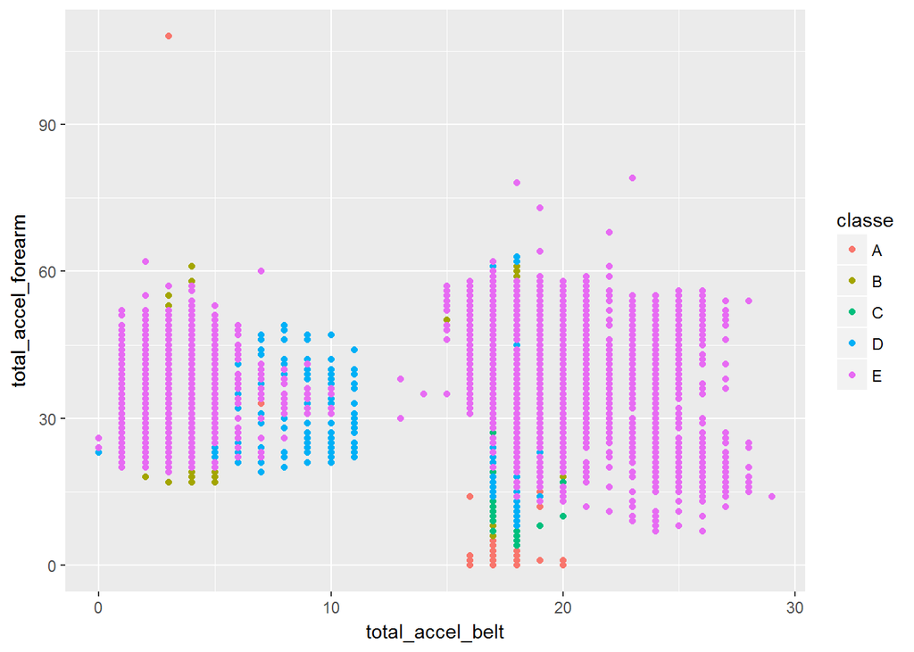

```r
plot1 <- ggplot(training, aes(total_accel_belt, total_accel_arm, colour = classe)) +
            geom_point(stat = 'identity')
plot2 <- ggplot(training, aes(total_accel_belt, total_accel_dumbbell, colour = classe)) +
            geom_point(stat = 'identity')
plot3 <- ggplot(training, aes(total_accel_belt, total_accel_forearm, colour = classe)) +
            geom_point(stat = 'identity')
plot4 <- ggplot(training, aes(total_accel_arm, total_accel_dumbbell, colour = classe)) +
            geom_point(stat = 'identity')
plot5 <- ggplot(training, aes(total_accel_arm, total_accel_forearm, colour = classe)) +
            geom_point(stat = 'identity')
plot6 <- ggplot(training, aes(total_accel_dumbbell, total_accel_forearm, colour = classe)) +
            geom_point(stat = 'identity')
plot3
```

### Correlation check

Removing correlated attributes by using findCorrelation function in caret package. Tree models are not affected significantly by using correlated attributes, but Regression model does.

```r
descrCor <- cor(training[, -53])
#summary(descrCor[upper.tri(descrCor)])
highlyCorDescr <- findCorrelation(descrCor, cutoff = .80)
training <- training[, -highlyCorDescr]
```

### Create training and testing dataset

10 folds cross validation is defined here, and will be used in train function as one parameter.

```r
set.seed(123456)
inTrain <- createDataPartition(y = training$classe, p = 0.8, list = FALSE)
cvTrain <- training[inTrain, ]
cvTest <- training[-inTrain, ]

fitCtrl <- trainControl(method = "repeatedcv", number = 10, repeats = 10)
```

### machine learning algorithm

As practice, I used other methods to build a model. I don’t display them as they take a large space in the analysis. RandomForest performs well here. Large number of trees will result better accuracy. However, it takes more resources and time to process. I use 20 trees based on condition of my computer. Preprocess is required here to improve accuracy as tree model are sensitive to scaled numeric data.

```r
set.seed(321)
rfFit <- train(classe ~ ., data = cvTrain, method = 'rf', ntree = 20, preProcess = c('center', 'scale'), trControl = fitCtrl)
```

### Prediction on test data is created by using the trained model.

```r
rfPred <- predict(rfFit, cvTest)
```

### Validation on testing dataset.

```r
cm <- confusionMatrix(rfPred, cvTest$classe)
cm
```

```
## Confusion Matrix and Statistics
##
##           Reference
## Prediction    A    B    C    D    E
##          A 1116   11    0    0    0
##          B    0  741    8    0    0
##          C    0    6  672    6    2
##          D    0    1    4  637    4
##          E    0    0    0    0  715
##
## Overall Statistics
##
##                Accuracy : 0.9893
##                  95% CI : (0.9856, 0.9923)
##     No Information Rate : 0.2845
##     P-Value [Acc > NIR] : < 2.2e-16
##
##                   Kappa : 0.9865
##  Mcnemar's Test P-Value : NA
##
## Statistics by Class:
##
##                      Class: A Class: B Class: C Class: D Class: E
## Sensitivity            1.0000   0.9763   0.9825   0.9907   0.9917
## Specificity            0.9961   0.9975   0.9957   0.9973   1.0000
## Pos Pred Value         0.9902   0.9893   0.9796   0.9861   1.0000
## Neg Pred Value         1.0000   0.9943   0.9963   0.9982   0.9981
## Prevalence             0.2845   0.1935   0.1744   0.1639   0.1838
## Detection Rate         0.2845   0.1889   0.1713   0.1624   0.1823
## Detection Prevalence   0.2873   0.1909   0.1749   0.1647   0.1823
## Balanced Accuracy      0.9980   0.9869   0.9891   0.9940   0.9958
```

### Out of sample error

Expected out of sample error is 0.01.

```r
sam.err <- round(1 - cm$overall['Accuracy'],2)
sam.err
```

```
## Accuracy
##     0.01
```

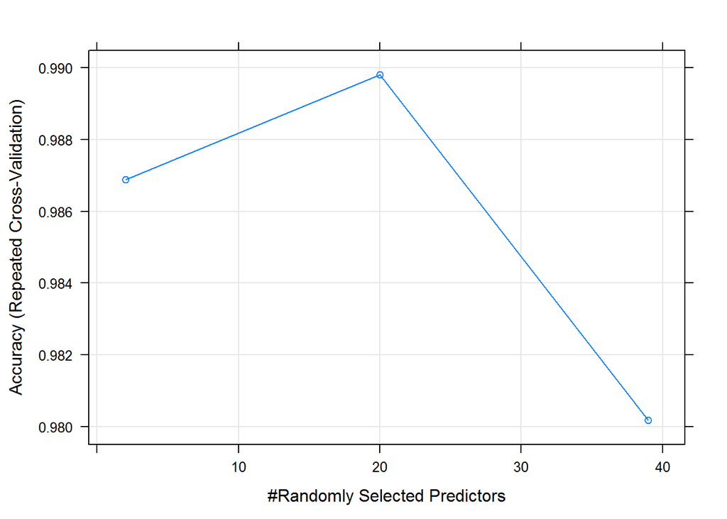

```r
plot(rfFit)
```

### Prediction on Test

```r
testPrediction <- predict(rfFit, newdata = test)
print(rbind(test[1:20, 160], as.character(testPrediction)))
```

```
##      [,1] [,2] [,3] [,4] [,5] [,6] [,7] [,8] [,9] [,10] [,11] [,12] [,13]
## [1,] "1"  "2"  "3"  "4"  "5"  "6"  "7"  "8"  "9"  "10"  "11"  "12"  "13"
## [2,] "B"  "A"  "B"  "A"  "A"  "E"  "D"  "B"  "A"  "A"   "B"   "C"   "B"
##      [,14] [,15] [,16] [,17] [,18] [,19] [,20]
## [1,] "14"  "15"  "16"  "17"  "18"  "19"  "20"
## [2,] "A"   "E"   "E"   "A"   "B"   "B"   "B"
```